← All reports

# 14 · Impact of removing the no-ads *sale* packs

**Question.** The `.sale` no-ads packs (`skip.ad.permanent.sale` $10.99, `skip.ad.30days.sale`, `skip.ad.annual.sale`) were removed from the client. When did that actually ship, and what did it do to revenue from new players?

**Project** `tiny-knightfall-idle-rpg-game.analytics_538412813` · **run** 2026-09-25 · follows `12_no_ads_sale_pack_removal.ipynb` (2026-09-18), which found the removal had *not* shipped in v28/v29.

**Design.** The `.sale` packs are a new-player offer — 98% of their purchases land within 2 days of install, none after day 6 — so removing them changes the **new-player funnel**. The fair comparison is **install cohorts at matched days since install**, not a version cut of active users (dominated by update-speed selection).

- **offer present** = installs **2026-09-10 → 09-20** (every build then live — 26.2, 28, 29 — still sold the packs; section 1)
- **offer absent** = installs whose `first_open` build is **v32 / v33 / v34**
- **China excluded from both.** A China install spike starts 09-19 (≈300/day vs ≈5 before), lands almost entirely on v29 and barely monetises. It is 45% of v29 installs but <1% of v32+, so leaving it in makes the removal look like it doubled revenue. See section 2.
- windows **D0, D0–D1, D0–D2**, each only over installs whose last window day is complete (≤ 2026-09-24; 09-25 is intraday) — so the short windows use more of the post-removal data.

**Caveats.** Revenue = `event_value_in_usd` on `in_app_purchase` (gross; non-US VAT included; no refunds in the export). Ad revenue = `value` on `ad_impression_MAX`. Not randomised: the arms are consecutive weeks with a different campaign mix, so section 4 reweights by campaign. The post-removal arm has a few hundred installs and a handful of payers — read the intervals.

## 1 · Did the removal ship, and in which build?

Every `.sale` signal by build since v28. `earn` is the decisive one — it is the client paying out the pack's reward and cannot fire from a removed shop card. (v29's 1,432 grants are `30days.sale`'s known ~230× re-emit, not 1,432 sales.)

```
Reusing cached data: C:\Users\Admin\Desktop\TinyKnight\parquet\nb14_ship_by_version.parquet
```

|  | v | first_day | last_day | users | installs | sale_taps | sale_buys | sale_grants | sale_success | last_sale_event |
| --- | --- | --- | --- | --- | --- | --- | --- | --- | --- | --- |
| 0 | 28 | 20260916 | 20260925 | 346 | 178 | 6 | 3 | 1 | 1 | 20260919 |
| 1 | 29 | 20260917 | 20260925 | 1981 | 1345 | 6 | 5 | 1432 | 2 | 20260925 |
| 2 | 30 | 20260920 | 20260925 | 13 | 11 | 0 | 0 | 0 | 0 | None |
| 3 | 31 | 20260920 | 20260923 | 14 | 11 | 0 | 0 | 0 | 0 | None |
| 4 | 32 | 20260921 | 20260925 | 460 | 234 | 0 | 0 | 0 | 0 | None |
| 5 | 33 | 20260923 | 20260925 | 429 | 270 | 0 | 0 | 0 | 0 | None |
| 6 | 34 | 20260925 | 20260925 | 65 | 48 | 0 | 0 | 0 | 0 | None |

## 2 · Per-install outcomes by day since install

One row per (player installed since 2026-09-10, day 0/1/2 since install).

```
Reusing cached data: C:\Users\Admin\Desktop\TinyKnight\parquet\nb14_install_cohort_by_dsi_v2.parquet
5,286 user-days, 3,931 installs, 2026-09-10 .. 2026-09-25
```

### The China spike — why it is excluded

| china install_date | rest | China | v29 share of China |
| --- | --- | --- | --- |
| 2026-09-15 | 171 | 6 | 0.00 |
| 2026-09-16 | 191 | 1 | 0.00 |
| 2026-09-17 | 207 | 8 | 0.00 |
| 2026-09-18 | 167 | 8 | 0.50 |
| 2026-09-19 | 134 | 297 | 0.98 |
| 2026-09-20 | 159 | 155 | 1.00 |
| 2026-09-21 | 153 | 81 | 0.95 |
| 2026-09-22 | 162 | 44 | 1.00 |
| 2026-09-23 | 172 | 22 | 1.00 |
| 2026-09-24 | 176 | 24 | 0.92 |
| 2026-09-25 | 144 | 16 | 0.75 |

```
D0–D2 $ per install:
```

|  | iap_usd | ad_usd |
| --- | --- | --- |
| rest | 0.357 | 0.079 |
| China | 0.000 | 0.000 |

## 3 · Offer present vs offer absent, per install

```
=== D0–D0 ===  (installs through 2026-09-24)
```

|  | offer present (installs 09-10..09-20) | offer absent (v32+) | change |
| --- | --- | --- | --- |
| installs | 2445.000 | 417.000 | -2028.000 |
| IAP payers | 30.000 | 6.000 | -24.000 |
| payer rate % | 1.227 | 1.439 | 0.212 |
| no-ads buyers /1k | 7.771 | 7.194 | -0.577 |
| .sale buyers /1k | 6.135 | 0.000 | -6.135 |
| full-price no-ads buyers /1k | 2.045 | 7.194 | 5.149 |
| no-ads taps /1k | 24.540 | 57.554 | 33.014 |
| IAP $/install | 0.236 | 0.319 | 0.082 |
| no-ads IAP $/install | 0.140 | 0.086 | -0.054 |
| other IAP $/install | 0.096 | 0.233 | 0.136 |
| IAP $/install excl. top payer | 0.205 | 0.221 | 0.016 |
| ad $/install | 0.069 | 0.097 | 0.028 |
| ad imps/install | 1.069 | 0.899 | -0.170 |
| total $/install | 0.306 | 0.416 | 0.110 |

```
=== D0–D1 ===  (installs through 2026-09-23)
```

|  | offer present (installs 09-10..09-20) | offer absent (v32+) | change |
| --- | --- | --- | --- |
| installs | 2445.000 | 255.000 | -2190.000 |
| IAP payers | 44.000 | 3.000 | -41.000 |
| payer rate % | 1.800 | 1.176 | -0.623 |
| no-ads buyers /1k | 12.270 | 3.922 | -8.348 |
| .sale buyers /1k | 10.225 | 0.000 | -10.225 |
| full-price no-ads buyers /1k | 2.454 | 3.922 | 1.468 |
| no-ads taps /1k | 26.585 | 62.745 | 36.160 |
| IAP $/install | 0.345 | 0.269 | -0.076 |
| no-ads IAP $/install | 0.202 | 0.054 | -0.148 |
| other IAP $/install | 0.143 | 0.215 | 0.072 |
| IAP $/install excl. top payer | 0.304 | 0.148 | -0.156 |
| ad $/install | 0.073 | 0.077 | 0.004 |
| ad imps/install | 1.174 | 1.212 | 0.038 |
| total $/install | 0.418 | 0.345 | -0.072 |

```
=== D0–D2 ===  (installs through 2026-09-22)
```

|  | offer present (installs 09-10..09-20) | offer absent (v32+) | change |
| --- | --- | --- | --- |
| installs | 2445.000 | 102.000 | -2343.000 |
| IAP payers | 46.000 | 3.000 | -43.000 |
| payer rate % | 1.881 | 2.941 | 1.060 |
| no-ads buyers /1k | 13.088 | 9.804 | -3.284 |
| .sale buyers /1k | 11.043 | 0.000 | -11.043 |
| full-price no-ads buyers /1k | 2.454 | 9.804 | 7.350 |
| no-ads taps /1k | 26.585 | 88.235 | 61.650 |
| IAP $/install | 0.385 | 0.671 | 0.286 |
| no-ads IAP $/install | 0.213 | 0.135 | -0.078 |
| other IAP $/install | 0.173 | 0.536 | 0.364 |
| IAP $/install excl. top payer | 0.339 | 0.371 | 0.032 |
| ad $/install | 0.075 | 0.129 | 0.054 |
| ad imps/install | 1.205 | 1.588 | 0.383 |
| total $/install | 0.461 | 0.801 | 0.340 |

### Bootstrap 90% intervals on (absent − present), $ per install

|  |  | diff | p5 | p95 |
| --- | --- | --- | --- | --- |
| D0–D0 | noads_usd | -0.054 | -0.148 | 0.055 |
|  | other_iap_usd | 0.136 | -0.029 | 0.317 |
|  | iap_usd | 0.082 | -0.158 | 0.360 |
|  | ad_usd | 0.028 | -0.017 | 0.083 |
|  | total_usd | 0.110 | -0.161 | 0.428 |
| D0–D1 | noads_usd | -0.148 | -0.249 | -0.030 |
|  | other_iap_usd | 0.072 | -0.130 | 0.317 |
|  | iap_usd | -0.076 | -0.343 | 0.237 |
|  | ad_usd | 0.004 | -0.031 | 0.043 |
|  | total_usd | -0.072 | -0.345 | 0.245 |
| D0–D2 | noads_usd | -0.078 | -0.261 | 0.196 |
|  | other_iap_usd | 0.364 | -0.111 | 0.961 |
|  | iap_usd | 0.286 | -0.323 | 1.030 |
|  | ad_usd | 0.054 | -0.015 | 0.138 |
|  | total_usd | 0.340 | -0.272 | 1.089 |

## 4 · Campaign mix, and a mix-adjusted comparison

Tier 1 ROAS campaigns monetise far better than organic/CPI traffic, so a shift in mix alone moves the headline. The adjusted row reweights each arm's per-campaign outcome to the *offer-present* arm's mix (campaigns with <10 installs in either arm pooled as "other").

| arm cgrp | offer present (installs 09-10..09-20) | offer absent (v32+) | offer present (installs 09-10..09-20) n | offer absent (v32+) n |
| --- | --- | --- | --- | --- |
| (unattributed) | 50.1 | 42.0 | 1225 | 107 |
| GA_TinyKnightfa_A_ROAS_Global_20072026 | 20.8 | 31.0 | 509 | 79 |
| GA_TinyKnightfa_A_ROAS_Tier1_150926 | 4.7 | 15.7 | 116 | 40 |
| Organic | 10.2 | 11.4 | 249 | 29 |
| other | 14.2 | 0.0 | 346 | 0 |

```
weights: {'(unattributed)': 0.584, 'GA_TinyKnightfa_A_ROAS_Global_20072026': 0.242, 'Organic': 0.119, 'GA_TinyKnightfa_A_ROAS_Tier1_150926': 0.055}
D0–D1, $ per install, reweighted to the offer-present campaign mix:
```

|  | offer present (installs 09-10..09-20) | offer absent (v32+) | change |
| --- | --- | --- | --- |
| noads_usd | 0.174 | 0.042 | -0.132 |
| other_iap_usd | 0.134 | 0.168 | 0.034 |
| iap_usd | 0.308 | 0.210 | -0.098 |
| ad_usd | 0.047 | 0.040 | -0.007 |
| total_usd | 0.354 | 0.250 | -0.104 |

## 5 · Chart

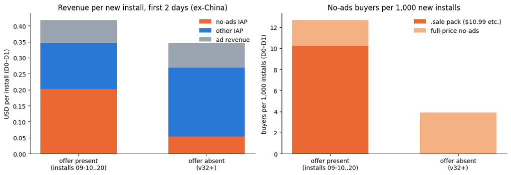

## 6 · Conclusion

**The removal shipped in v32 (live 2026-09-21).** v32, v33 and v34 show zero `.sale` taps, purchases, reward grants or purchase successes across ~950 users and ~550 installs, while v28/v29 were still selling them through today. Nothing is gone from the older builds — players who stay on v29 still see the offer.

**Early read (ex-China, new installs, D0–D1 — the window with the most post-removal data):**

[output not shown]

- **The one clear effect: early no-ads revenue fell ~70–75%.** `.sale` buyers were 10.2 per 1,000 installs by D1; the full-price no-ads SKUs picked up only 3.9 per 1,000 after (2.5 before).
- **Players are looking for the offer.** No-ads taps per install rose ~2.4× (26.5 → 62.7 per 1k) — they open the no-ads card, see $29.99 instead of $10.99, and mostly don't buy.
- **Some substitution on install day**: full-price no-ads buyers went 2.0 → 7.2 per 1k on D0 — but that is **3 buyers**, so it cannot yet tell 15% substitution from 80%.
- **Total revenue per install: down ~$0.07–0.10 (≈ 17–29%), but not statistically distinguishable from zero.** Other IAP and ad revenue have not visibly compensated. At ~1,100 non-China installs a week that is roughly **−$80–115/week of first-2-day revenue**, concentrated in the no-ads line.
- Ads per install did not rise — so far no sign that players who can no longer cheaply remove ads are generating more ad revenue in their first days (it would show later, if at all).

**How much to trust it.** The post-removal arm is 255 installs with 3 payers over D0–D1 (417 / 6 on D0; 102 / 3 on D0–D2). The no-ads drop is robust; the net-revenue direction is not. The arms are consecutive weeks and the later one has more Tier 1 ROAS traffic (reweighting makes the drop slightly *larger*). Gross revenue only; no refunds in the export — and `permanent.sale` was the most-refunded SKU (7 of 20 Play refunds in 30 days), so some of the lost gross was never kept.

**China install spike — exclude it everywhere.** From 2026-09-19 China jumped from ~5 to ~300 installs/day, 98% on v29, with **$0.00 IAP and $0.00 ad revenue** per install over D0–D2. It looks like non-Play (mirror/bot) traffic, and it is inflating install counts on the dashboards.

**Next step.** Re-run this notebook in about a week, when ~1,000 v32+ installs have a complete D0–D2, and add D7. Because `bq_helper` reuses the parquet cache when the SQL is byte-identical, delete `parquet/nb14_*` (or pass `force=True`) first, or it will show today's numbers again.